# Detect chromosomal duplications

Author

Claudia Zirión-Martínez

Published

February 13, 2025

## Setup

```r
library(tidyverse)
library(ggbeeswarm)
library(ggtree)
library(ggtreeExtra)
library(ape)
library(phytools)
library(ggnewscale)
library(RColorBrewer)
setwd("/FastData/czirion/Crypto_Diversity_Pipeline/analyses/tree_duplications/scripts")
```

## Metadata

Use the metadata table that has all the samples included in the final Crypto_Desjardins_Ashton dataset (n = 1055) and H99 .

```r
metadata <- read.delim(
    "../../data/processed/metadata_ashton_desj_all_fungalpop_H99.csv",
    header=TRUE,
    sep=",",
    stringsAsFactor = TRUE)
```

Select needed columns, remove H99 and get the number of samples per dataset and lineage, per lineage, and total.

```r
metadata <- metadata %>%
    select(sample, strain, source, lineage, dataset, vni_subdivision)%>%
    filter(!strain == "H99") %>%
    group_by(dataset, lineage)%>%
    mutate(samples_in_dataset_lineage = n_distinct(sample))%>%
    ungroup() %>%
    group_by(lineage)%>%
    mutate(samples_in_lineage = n_distinct(sample))%>%
    ungroup()%>%
    mutate(total_samples = n_distinct(sample))
```

## Chromosome names and length

Get the nice chromosome names

```r
chromosome_names = read.delim(
    "../../../Crypto_Desjardins_Ashton/results_joined/02.Dataset/chromosomes.csv",
    header=TRUE, sep=",")
chromosome_names <- chromosome_names %>%
    mutate(chromosome = str_pad(chromosome, 2, pad = "0"))%>%
    mutate(chromosome = as.factor(chromosome))
levels(chromosome_names$chromosome) <- paste("chr", chromosome_names$chromosome, sep="")
```

Get the chromosome lengths

```bash
# /usr/bin/bash
tail -n +2 ../../../Crypto_Desjardins/config/chromosomes.csv | \
    cut -d',' -f1 | sort | uniq | while read line \
do
seqkit fx2tab ../../../Crypto_Desjardins/data/references/$line.fasta \
    -l -i -n >> ../../data/processed/chromosome_lengths.tsv
done
```

```r
chromosome_lengths = read.delim(
    "../../data/processed/chromosome_lengths.tsv",
    header=FALSE,
    col.names=c("accession", "length"),
    sep="\t")
```

## Get metrics of chromosomes from called CNVs

```r
cnv_calls <- read.delim(
    "../../../Crypto_Desjardins_Ashton/results_joined/02.Dataset/cnv/cnv_calls.tsv",
    header=TRUE, sep="\t")
```

Define a threshold of allowed fraction of repetitive sequences in called CNV regions.

```r
repeat_fraction_threshold <- 0.2
```

Get the percentage of the size of each chromosome that is part of called duplications `percent_cnv_size` and the percentage of the size of the chromosome that is in between the leftmost and rightmost duplicated regions `percent_size_covered`.

```r
cnv_percent <- cnv_calls %>%
    filter(repeat_fraction < repeat_fraction_threshold) %>%
    filter(cnv == "duplication")%>%
    group_by(accession, sample, cnv) %>%
    summarise(total_cnv_size = sum(region_size),
                n_cnvs = n(),
                first = min(start),
                last = max(end),
                mean_cnv_depth = round(mean(smooth_depth),2)) %>%
    left_join(chromosome_lengths, by="accession") %>%
    left_join(chromosome_names, by="accession") %>%
    left_join(metadata, by=c("sample", "lineage")) %>%
    mutate(percent_cnv_size = round((total_cnv_size / length) * 100, 2),
            size_covered = last - first,
            percent_size_covered = round((size_covered / length) * 100, 2))%>%
    mutate(chromosome = as.factor(chromosome)) %>%
    select(dataset,lineage, samples_in_lineage, samples_in_dataset_lineage,
    total_samples, sample,strain, source, accession, chromosome,
    percent_cnv_size, percent_size_covered, mean_cnv_depth, n_cnvs)
```

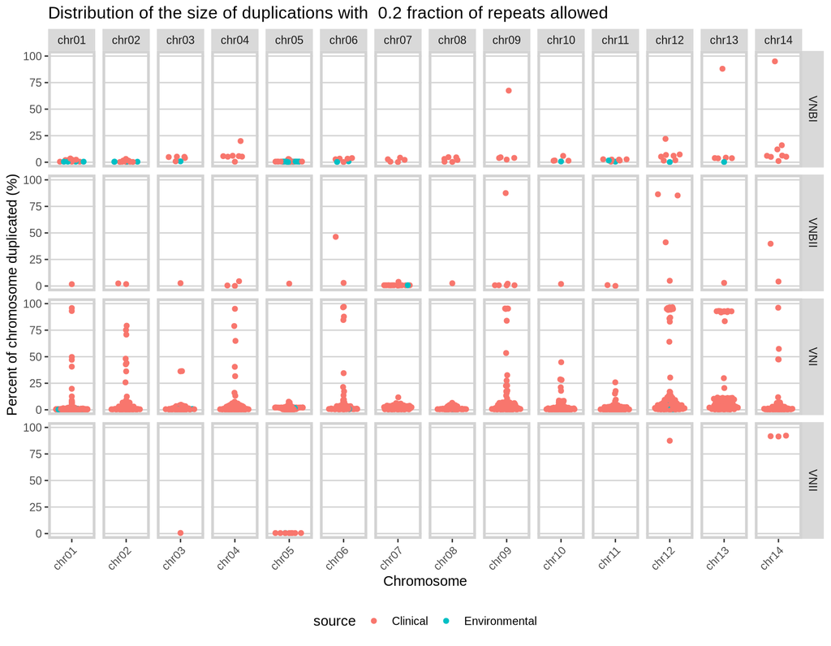

Get the percentage of each chromosome covered by repeats to know how much of a chromosome might not have reliable CNV calls.

```r
lineages <- unique(metadata$lineage)
repeats_all <- data.frame()
for(lineage in lineages){
    repeats_path <-paste(
        "../../../Crypto_Desjardins/results/03.References/",
        lineage, "/", lineage, "_repeats.bed",
        sep ="")
    repeats <- read.delim(repeats_path,
        header=FALSE,
        col.names=c("accession", "start", "end", "repeat_type"),
        sep="\t")
    repeats$lineage <- lineage
    repeats_all <- rbind(repeats_all, repeats)
}
```

```r
repeats_percent <- repeats_all %>%
    mutate(repeat_size_each = end - start)%>%
    group_by(accession, lineage) %>%
    summarise(repeat_size = sum(repeat_size_each)) %>%
    left_join(chromosome_lengths, by="accession") %>%
    left_join(chromosome_names, by=c("accession","lineage")) %>%
    mutate(percent_repeat_size = round((repeat_size / length) * 100, 2))%>%
    mutate(chromosome = as.factor(chromosome))%>%
    select(lineage, accession, chromosome, percent_repeat_size)
```

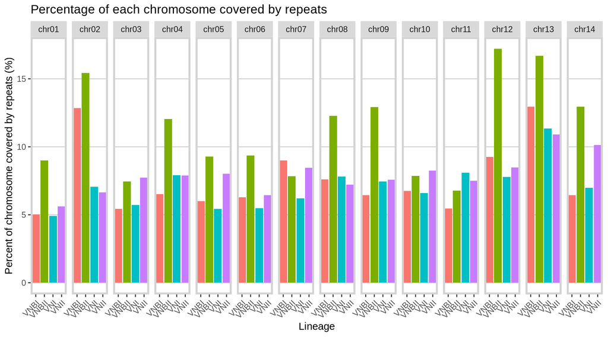

Most chromosomes have repeats in between 5 and 10% of the size. In VNBII it is closer to 15% for some chormosomes.

## Get the chromosome median depth as another measure to dectect duplicated chromosomes

```r
depth_by_chrom_good_desjardins <- read.delim(
    "../../../Crypto_Desjardins/results/04.Intermediate_files/02.Dataset/depth_quality/depth_by_chrom_good.tsv",
     header=TRUE, sep="\t")
depth_by_chrom_good_ashton <- read.delim(
    "../../../Crypto_Ashton/results/04.Intermediate_files/02.Dataset/depth_quality/depth_by_chrom_good.tsv",
     header=TRUE, sep="\t")
depth_by_chrom_good <- rbind(depth_by_chrom_good_desjardins, depth_by_chrom_good_ashton)
depth_by_chrom <- depth_by_chrom_good %>%
    select(sample, accession, norm_chrom_median)
```

## Join CNV metrics with normalized chromosome depth

```r
cnv_and_depth <- left_join(depth_by_chrom, cnv_percent, by = c("sample", "accession" ))
```

Make a threshold for the size of the chromosome that must be in called duplicated regions and a threshold for the normalized chromosome median depth.

```r
percent_size_threshold <- 80
depth_threshold <- 1.55
```

Keep, as putative duplications, the chromosomes whose metrics are above any of the thresholds.

```r
duplications <- cnv_and_depth %>%
    filter(norm_chrom_median > depth_threshold | percent_cnv_size > percent_size_threshold)%>%
    select(dataset, lineage, samples_in_lineage, samples_in_dataset_lineage,
        total_samples, source, strain, sample, chromosome, norm_chrom_median,
        mean_cnv_depth, percent_cnv_size, percent_size_covered, n_cnvs)
```

```r
head(select(duplications, strain, chromosome,
    norm_chrom_median, mean_cnv_depth, percent_cnv_size,
    percent_size_covered, n_cnvs))
```

| strain | chromosome | norm_chrom_median | mean_cnv_depth | percent_cnv_size | percent_size_covered | n_cnvs |
| --- | --- | --- | --- | --- | --- | --- |
| Bt134 | chr12 | 2.02 | 1.85 | 95.86 | 97.67 | 2 |
| 8-1 | chr14 | 2.03 | 1.90 | 92.26 | 96.56 | 2 |
| Bt109 | chr09 | 1.97 | 1.87 | 87.54 | 94.24 | 4 |
| MW-RSA3834 | chr12 | 1.97 | 1.88 | 95.15 | 97.34 | 2 |
| LP-RSA3042 | chr14 | 1.92 | 1.82 | 96.14 | 98.53 | 3 |
| WM626 | chr14 | 2.15 | 2.04 | 91.72 | 95.95 | 2 |

Write the duplications table to a table to use it in the scripts `duplications_gather_plots.xsh` and `duplications_polish.qmd` to polish the results.

```r
dir.create("../results/tables/putative", recursive = TRUE)
write_tsv(duplications, "../results/tables/duplications_putative.tsv")
```

Plot all metrics of putative duplications.

```r
duplications_long <- duplications  %>%
    arrange(percent_cnv_size) %>%
    mutate(chrom_sample = paste(chromosome, sample, sep="_"))
duplications_long$chrom_sample <- factor(duplications_long$chrom_sample,
    levels = duplications_long$chrom_sample)
duplications_long <- pivot_longer(duplications_long,
    cols = c("norm_chrom_median", "mean_cnv_depth",
        "percent_cnv_size", "percent_size_covered",
        "n_cnvs"),
    names_to = "variable",
    values_to = "value")
duplications_long$variable <- factor(duplications_long$variable,
    levels = c("norm_chrom_median", "mean_cnv_depth",
        "percent_cnv_size", "percent_size_covered",
        "n_cnvs"))
```

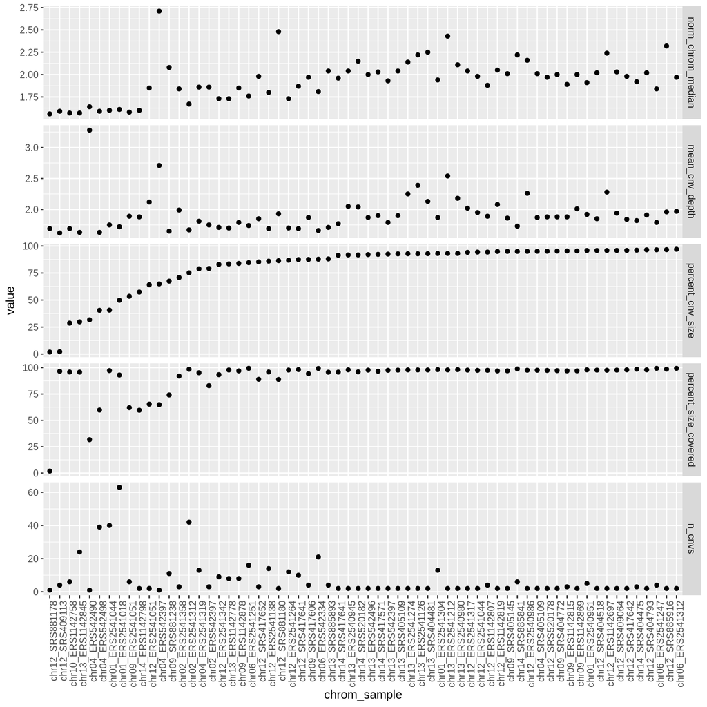

## Get multiple summary tables

Number of duplicated chromosomes per sample.

```r
dup_sample <- duplications %>%
    group_by(dataset,lineage, sample, strain, source) %>%
    summarise(n_chroms = n_distinct(chromosome),
            chromosomes = paste(chromosome, collapse = ", ")) %>%
    arrange(desc(n_chroms))
dup_sample
```

| dataset | lineage | sample | strain | source | n_chroms | chromosomes |
| --- | --- | --- | --- | --- | --- | --- |
| Ashton | VNI | ERS542397 | 14936_1#6 | Clinical | 3 | chr02, chr04, chr13 |
| Ashton | VNI | ERS2541044 | 04CN-64-074 | Clinical | 2 | chr01, chr12 |
| Ashton | VNI | ERS2541051 | 04CN-65-032 | Clinical | 2 | chr09, chr12 |
| Ashton | VNI | ERS2541312 | 04CN-32-011 | Clinical | 2 | chr02, chr06 |
| Desjardins | VNI | SRS405109 | Bt92 | Clinical | 2 | chr04, chr13 |
| Desjardins | VNII | SRS417641 | C12 | Clinical | 2 | chr12, chr14 |
| Ashton | VNI | ERS1142697 | 20427_2#6 | Clinical | 1 | chr12 |
| Ashton | VNI | ERS1142758 | 20427_2#61 | Clinical | 1 | chr10 |
| Ashton | VNI | ERS1142778 | 20949_2#15 | Clinical | 1 | chr13 |
| Ashton | VNI | ERS1142798 | 20949_2#21 | Clinical | 1 | chr14 |
| Ashton | VNI | ERS1142807 | 20427_3#21 | Clinical | 1 | chr12 |
| Ashton | VNI | ERS1142815 | 20427_3#26 | Clinical | 1 | chr09 |
| Ashton | VNI | ERS1142819 | 20427_3#30 | Clinical | 1 | chr12 |
| Ashton | VNI | ERS1142845 | 20427_3#51 | Clinical | 1 | chr13 |
| Ashton | VNI | ERS1142869 | 20949_2#42 | Clinical | 1 | chr09 |
| Ashton | VNI | ERS1142878 | 20427_4#13 | Clinical | 1 | chr09 |
| Ashton | VNI | ERS2540945 | 04CN-65-072 | Clinical | 1 | chr13 |
| Ashton | VNI | ERS2540951 | 04CN-64-024 | Clinical | 1 | chr01 |
| Ashton | VNI | ERS2540980 | 04CN-64-011 | Clinical | 1 | chr13 |
| Ashton | VNI | ERS2540986 | 04CN-65-001 | Clinical | 1 | chr12 |
| Ashton | VNI | ERS2541018 | 04CN-64-128 | Clinical | 1 | chr01 |
| Ashton | VNI | ERS2541126 | BMD3144 | Clinical | 1 | chr13 |
| Ashton | VNI | ERS2541138 | 04CN-03-053 | Clinical | 1 | chr12 |
| Ashton | VNI | ERS2541212 | 04CN-03-039 | Clinical | 1 | chr13 |
| Ashton | VNI | ERS2541247 | BMD2209 | Clinical | 1 | chr06 |
| Ashton | VNI | ERS2541251 | 04CN-03-081 | Clinical | 1 | chr06 |
| Ashton | VNI | ERS2541264 | BMD3117 | Clinical | 1 | chr12 |
| Ashton | VNI | ERS2541274 | BMD761 | Clinical | 1 | chr13 |
| Ashton | VNI | ERS2541304 | 04CN-65-056 | Clinical | 1 | chr01 |
| Ashton | VNI | ERS2541317 | 04CN-64-090 | Clinical | 1 | chr12 |
| Ashton | VNI | ERS2541319 | 04CN-32-042 | Clinical | 1 | chr04 |
| Ashton | VNI | ERS2541342 | UI_31647-2 | Clinical | 1 | chr12 |
| Ashton | VNI | ERS2541358 | CNS_936 | Clinical | 1 | chr02 |
| Ashton | VNI | ERS542334 | 14892_1#38 | Clinical | 1 | chr06 |
| Ashton | VNI | ERS542490 | 14893_1#4 | Clinical | 1 | chr04 |
| Ashton | VNI | ERS542496 | 14893_1#10 | Clinical | 1 | chr13 |
| Ashton | VNI | ERS542498 | 14893_1#12 | Clinical | 1 | chr04 |
| Desjardins | VNBI | SRS881178 | NRHc5005.ENR | Clinical | 1 | chr12 |
| Desjardins | VNBI | SRS881238 | PMHc1026.ENR | Clinical | 1 | chr09 |
| Desjardins | VNBI | SRS885841 | NRHc5009.REL.INI | Clinical | 1 | chr14 |
| Desjardins | VNBI | SRS885893 | NRHc5045.ENR.CLIN.ISO | Clinical | 1 | chr13 |
| Desjardins | VNBII | SRS417606 | Bt109 | Clinical | 1 | chr09 |
| Desjardins | VNBII | SRS417652 | MW-RSA2967 | Clinical | 1 | chr12 |
| Desjardins | VNBII | SRS881180 | PMHc1029.ENR.STOR | Clinical | 1 | chr12 |
| Desjardins | VNI | SRS404475 | LP-RSA3042 | Clinical | 1 | chr14 |
| Desjardins | VNI | SRS404481 | Bt139 | Clinical | 1 | chr13 |
| Desjardins | VNI | SRS404518 | Bt134 | Clinical | 1 | chr12 |
| Desjardins | VNI | SRS404772 | Bt141 | Clinical | 1 | chr09 |
| Desjardins | VNI | SRS404793 | MW-RSA6134 | Clinical | 1 | chr12 |
| Desjardins | VNI | SRS405145 | Bt117 | Clinical | 1 | chr09 |
| Desjardins | VNI | SRS409064 | MW-RSA1955 | Clinical | 1 | chr12 |
| Desjardins | VNI | SRS409113 | Br795 | Clinical | 1 | chr12 |
| Desjardins | VNI | SRS417642 | In2632 | Clinical | 1 | chr12 |
| Desjardins | VNI | SRS520178 | MW-RSA3834 | Clinical | 1 | chr12 |
| Desjardins | VNI | SRS885916 | PMHc1031A.ENR.INI.LP | Clinical | 1 | chr12 |
| Desjardins | VNII | SRS417571 | 8-1 | Clinical | 1 | chr14 |
| Desjardins | VNII | SRS520182 | WM626 | Clinical | 1 | chr14 |

Number of samples with duplications in each group of dataset-lineage-chromosome.

```r
dup_dataset_lineage_chromosome <- duplications %>%
    group_by(dataset,lineage, chromosome) %>%
    summarise(n_samples = n_distinct(sample),
            samples_in_dataset_lineage = first(samples_in_dataset_lineage))%>%
    mutate(percent_samples = round((n_samples / samples_in_dataset_lineage) * 100, 1))%>%
    select(dataset,lineage, chromosome,
            n_samples, samples_in_dataset_lineage, percent_samples)%>%
    arrange(chromosome, desc(lineage), desc(n_samples))
dup_dataset_lineage_chromosome
```

| dataset | lineage | chromosome | n_samples | samples_in_dataset_lineage | percent_samples |
| --- | --- | --- | --- | --- | --- |
| Ashton | VNI | chr01 | 4 | 668 | 0.6 |
| Ashton | VNI | chr02 | 3 | 668 | 0.4 |
| Ashton | VNI | chr04 | 4 | 668 | 0.6 |
| Desjardins | VNI | chr04 | 1 | 185 | 0.5 |
| Ashton | VNI | chr06 | 4 | 668 | 0.6 |
| Ashton | VNI | chr09 | 4 | 668 | 0.6 |
| Desjardins | VNI | chr09 | 2 | 185 | 1.1 |
| Desjardins | VNBII | chr09 | 1 | 64 | 1.6 |
| Desjardins | VNBI | chr09 | 1 | 122 | 0.8 |
| Ashton | VNI | chr10 | 1 | 668 | 0.1 |
| Desjardins | VNII | chr12 | 1 | 16 | 6.2 |
| Ashton | VNI | chr12 | 10 | 668 | 1.5 |
| Desjardins | VNI | chr12 | 7 | 185 | 3.8 |
| Desjardins | VNBII | chr12 | 2 | 64 | 3.1 |
| Desjardins | VNBI | chr12 | 1 | 122 | 0.8 |
| Ashton | VNI | chr13 | 9 | 668 | 1.3 |
| Desjardins | VNI | chr13 | 2 | 185 | 1.1 |
| Desjardins | VNBI | chr13 | 1 | 122 | 0.8 |
| Desjardins | VNII | chr14 | 3 | 16 | 18.8 |
| Ashton | VNI | chr14 | 1 | 668 | 0.1 |
| Desjardins | VNI | chr14 | 1 | 185 | 0.5 |
| Desjardins | VNBI | chr14 | 1 | 122 | 0.8 |

Number of samples with duplications in each group of lineage-chromosome.

```r
dup_lineage_chromosome <- duplications%>%
    group_by(lineage, chromosome) %>%
    summarise(n_samples = n_distinct(sample), samples_in_lineage = first(samples_in_lineage))%>%
    mutate(percent_samples = round((n_samples / samples_in_lineage) * 100, 1))%>%
    select(lineage, chromosome, n_samples, samples_in_lineage,percent_samples)%>%
    arrange(chromosome, desc(lineage), desc(n_samples))
dup_lineage_chromosome
```

| lineage | chromosome | n_samples | samples_in_lineage | percent_samples |
| --- | --- | --- | --- | --- |
| VNI | chr01 | 4 | 853 | 0.5 |
| VNI | chr02 | 3 | 853 | 0.4 |
| VNI | chr04 | 5 | 853 | 0.6 |
| VNI | chr06 | 4 | 853 | 0.5 |
| VNI | chr09 | 6 | 853 | 0.7 |
| VNBII | chr09 | 1 | 64 | 1.6 |
| VNBI | chr09 | 1 | 122 | 0.8 |
| VNI | chr10 | 1 | 853 | 0.1 |
| VNII | chr12 | 1 | 16 | 6.2 |
| VNI | chr12 | 17 | 853 | 2.0 |
| VNBII | chr12 | 2 | 64 | 3.1 |
| VNBI | chr12 | 1 | 122 | 0.8 |
| VNI | chr13 | 11 | 853 | 1.3 |
| VNBI | chr13 | 1 | 122 | 0.8 |
| VNII | chr14 | 3 | 16 | 18.8 |
| VNI | chr14 | 2 | 853 | 0.2 |
| VNBI | chr14 | 1 | 122 | 0.8 |

Number of samples with duplications in each group of lineage-datset.

```r
dup_lineage_dataset <- duplications%>%
    group_by(dataset,lineage) %>%
    summarise(n_samples = n_distinct(sample),
        samples_in_dataset_lineage = first(samples_in_dataset_lineage))%>%
    mutate(percent_samples = round((n_samples / samples_in_dataset_lineage) * 100, 1))%>%
    select(lineage, n_samples, samples_in_dataset_lineage, percent_samples)%>%
    arrange(desc(lineage), desc(n_samples))
dup_lineage_dataset
```

| dataset | lineage | n_samples | samples_in_dataset_lineage | percent_samples |
| --- | --- | --- | --- | --- |
| Desjardins | VNII | 3 | 16 | 18.8 |
| Ashton | VNI | 35 | 668 | 5.2 |
| Desjardins | VNI | 12 | 185 | 6.5 |
| Desjardins | VNBII | 3 | 64 | 4.7 |
| Desjardins | VNBI | 4 | 122 | 3.3 |

Number of samples with duplications in each chromosome.

```r
dup_chromosome <- duplications %>%
    group_by(chromosome) %>%
    summarise(n_samples = n_distinct(sample), total_samples = first(total_samples))%>%
    mutate(percent_samples = round((n_samples / total_samples) * 100, 1))%>%
    select(chromosome, n_samples,total_samples, percent_samples)%>%
    arrange(chromosome, desc(n_samples))
dup_chromosome
```

| chromosome | n_samples | total_samples | percent_samples |
| --- | --- | --- | --- |
| chr01 | 4 | 1055 | 0.4 |
| chr02 | 3 | 1055 | 0.3 |
| chr04 | 5 | 1055 | 0.5 |
| chr06 | 4 | 1055 | 0.4 |
| chr09 | 8 | 1055 | 0.8 |
| chr10 | 1 | 1055 | 0.1 |
| chr12 | 21 | 1055 | 2.0 |
| chr13 | 12 | 1055 | 1.1 |
| chr14 | 6 | 1055 | 0.6 |